# Exploratory Data Analysis (EDA)

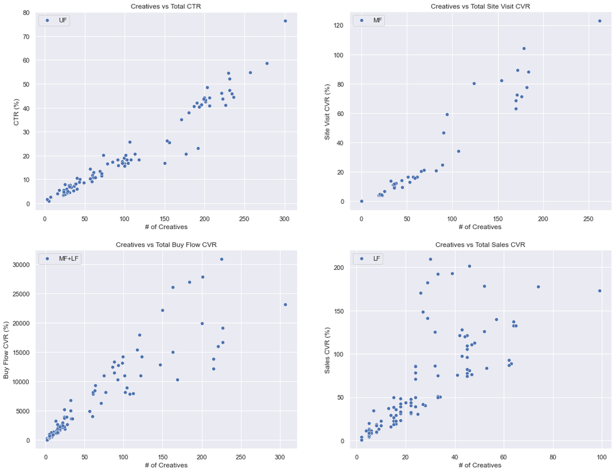

```python
# Plot number of creatives against KPIs
fig, ax = plt.subplots(2, 2, figsize=(18, 14))

# CTR
sns.scatterplot(x='In_Market_UF', y='Total_CTR', data=plo_df, label='UF', ax=ax[0,0])
ax[0,0].set_title('Creatives vs Total CTR')
ax[0,0].set_xlabel('# of Creatives')
ax[0,0].set_ylabel('CTR (%)')
ax[0,0].legend()

# Site visit CVR
sns.scatterplot(x='In_Market_MF', y='Total_Site_Visit_CVR', data=plo_df, label='MF', ax=ax[0,1])
ax[0,1].set_title('Creatives vs Total Site Visit CVR')
ax[0,1].set_xlabel('# of Creatives')
ax[0,1].set_ylabel('Site Visit CVR (%)')
ax[0,1].legend()

# MF+LF Buy flow CVR
sns.scatterplot(x='In_Market_MF_LF', y='Total_Buy_Flow_CVR_MF_LF', label='MF+LF', data=plo_df, ax=ax[1,0])
ax[1,0].set_title('Creatives vs Total Buy Flow CVR')
ax[1,0].set_xlabel('# of Creatives')
ax[1,0].set_ylabel('Buy Flow CVR (%)')
ax[1,0].legend(loc='upper left')

# LF Sales CVR
sns.scatterplot(x='In_Market_LF', y='Total_Sales_CVR', data=plo_df, label='LF', ax=ax[1,1])
ax[1,1].set_title('Creatives vs Total Sales CVR')
ax[1,1].set_xlabel('# of Creatives')
ax[1,1].set_ylabel('Sales CVR (%)')
ax[1,1].legend(loc='upper left')

plt.show()
```

The relationship between funnel specific number of creatives and KPI follow a positive relationship. Since Buy Flow CVR measure activity in both the middle and lower funnels, we will split these accordingly to see how each creative impacts the KPI. We can also see some unusual observations for Site Visit CVR, perhaps splitting these into middle and lower funnel is helpful to distinguish relationships. Additionally, we can see some forms of heteroskedasticity in buy flow and sales CVR as the number of creatives increases.

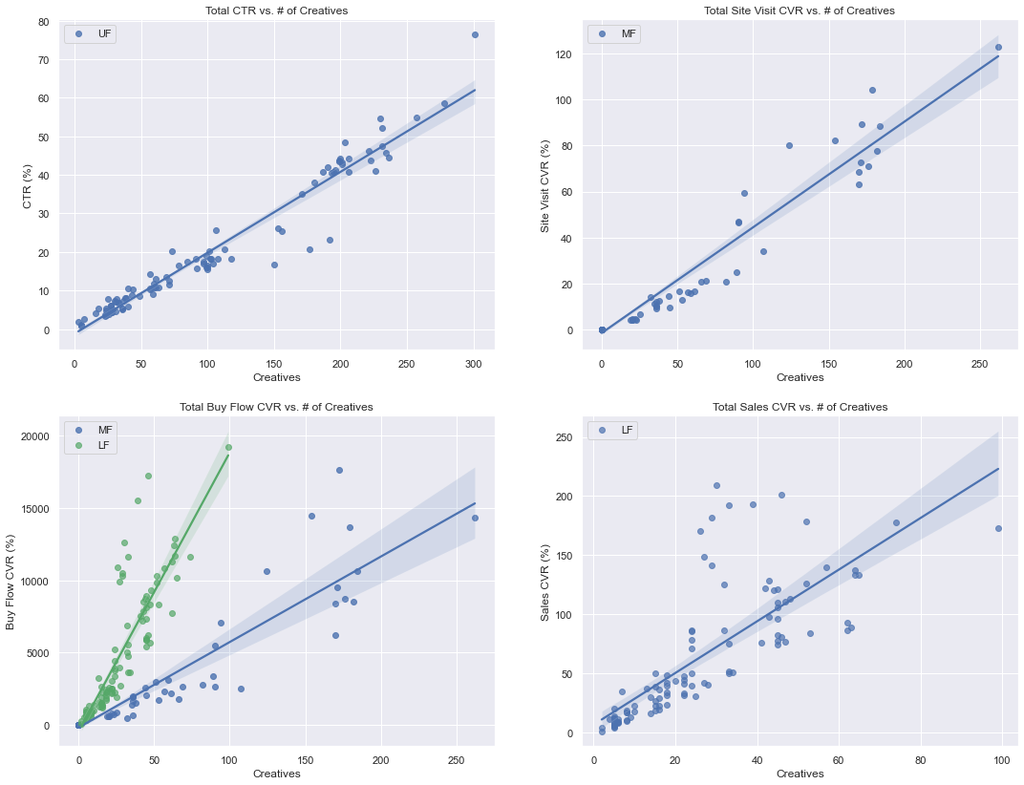

```python
# Plot number of creatives against KPIs
fig, ax = plt.subplots(2, 2, figsize=(18, 14))

# CTR
sns.regplot(x='In_Market_UF', y='Total_CTR', data=plo_df, label='UF', ax=ax[0,0])
ax[0,0].set_title('Total CTR vs. # of Creatives')
ax[0,0].set_xlabel('Creatives')
ax[0,0].set_ylabel('CTR (%)')
ax[0,0].legend()

# Site visit CVR
sns.regplot(x='In_Market_MF', y='Total_Site_Visit_CVR', data=plo_df, label='MF', ax=ax[0,1])
ax[0,1].set_title('Total Site Visit CVR vs. # of Creatives')
ax[0,1].set_xlabel('Creatives')
ax[0,1].set_ylabel('Site Visit CVR (%)')
ax[0,1].legend(loc='upper left')

# MF Buy flow CVR
sns.regplot(x='In_Market_MF', y='Total_Buy_Flow_CVR_MF', label='MF', data=plo_df, ax=ax[1,0])
# LF Buy flow CVR
sns.regplot(x='In_Market_LF', y='Total_Buy_Flow_CVR_LF', label='LF', data=plo_df,
    scatter_kws={'color':'g', 'alpha':.7}, line_kws={'color':'g'}, ax=ax[1,0])

ax[1,0].set_title('Total Buy Flow CVR vs. # of Creatives')
ax[1,0].set_xlabel('Creatives')
ax[1,0].set_ylabel('Buy Flow CVR (%)')
ax[1,0].legend(loc='upper left')

# LF Sales CVR
sns.regplot(x='In_Market_LF', y='Total_Sales_CVR', data=plo_df, label='LF',
    scatter_kws={'alpha':.7}, ax=ax[1,1])

ax[1,1].set_title('Total Sales CVR vs. # of Creatives')
ax[1,1].set_xlabel('Creatives')
ax[1,1].set_ylabel('Sales CVR (%)')
ax[1,1].legend(loc='upper left')

plt.show()
```

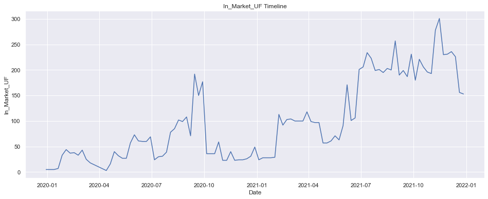

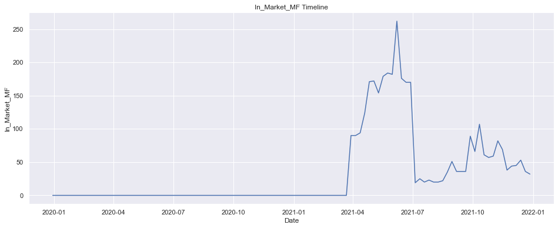

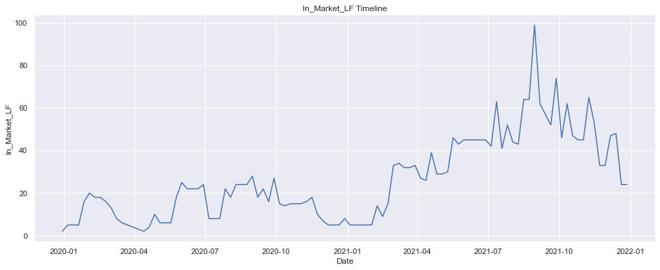

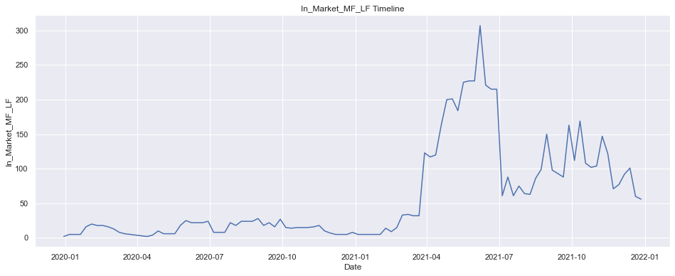

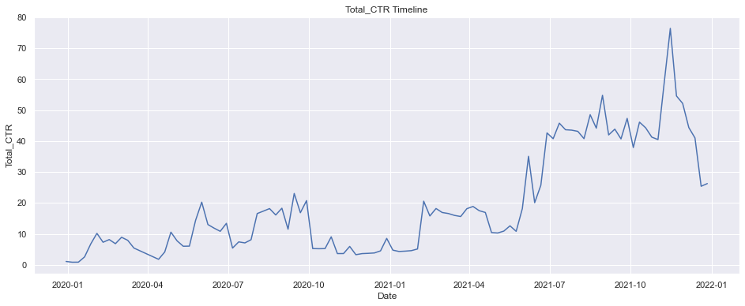

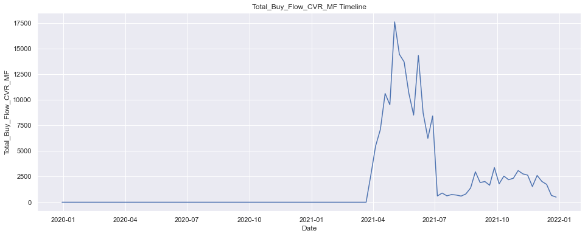

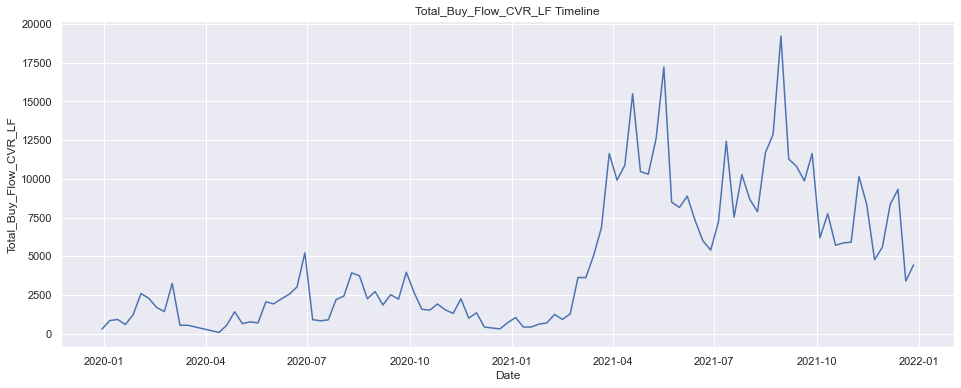

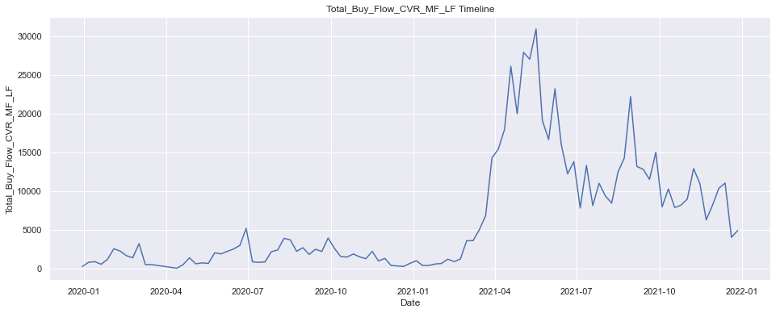

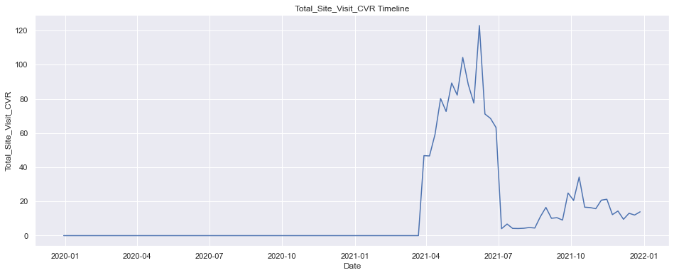

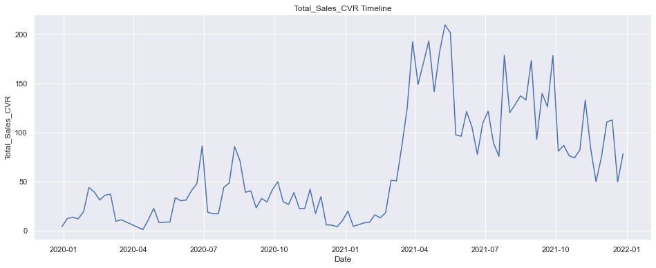

```python
# Check stationarity with plot
for col in plo_df.columns:
    plt.figure(figsize=(16, 6))
    plt.plot(plo_df[col])
    plt.title(f'{col} Timeline')
    plt.xlabel('Date')
    plt.ylabel(f'{col}')
    plt.show()
```

Clearly, the data is not stationary with a mean of zero and constant variance. Nevertheless, we will run one regression on the level series to see its results.

```python
# UF CTR level series regression model
reg = smf.ols(formula='Total_CTR ~ In_Market_UF', data=plo_df).fit()
reg.summary()
```

OLS Regression Results

| Dep. Variable: | Total_CTR | R-squared: | 0.948 |
| --- | --- | --- | --- |
| Model: | OLS | Adj. R-squared: | 0.947 |
| Method: | Least Squares | F-statistic: | 1805. |
| Date: | Tue, 05 Apr 2022 | Prob (F-statistic): | 8.28e-66 |
| Time: | 22:02:33 | Log-Likelihood: | -282.29 |
| No. Observations: | 102 | AIC: | 568.6 |
| Df Residuals: | 100 | BIC: | 573.8 |
| Df Model: | 1 |  |  |
| Covariance Type: | nonrobust |  |  |

|  | coef | std err | t | P>\|t\| | [0.025 | 0.975] |
| --- | --- | --- | --- | --- | --- | --- |
| Intercept | -1.2111 | 0.627 | -1.932 | 0.056 | -2.455 | 0.032 |
| In_Market_UF | 0.2099 | 0.005 | 42.485 | 0.000 | 0.200 | 0.220 |

| Omnibus: | 39.113 | Durbin-Watson: | 0.632 |
| --- | --- | --- | --- |
| Prob(Omnibus): | 0.000 | Jarque-Bera (JB): | 191.786 |
| Skew: | -1.094 | Prob(JB): | 2.26e-42 |
| Kurtosis: | 9.351 | Cond. No. | 206. |

Notes:  
[1] Standard Errors assume that the covariance matrix of the errors is correctly specified.

This simple linear regression yielded an adjusted r-squared value of 0.947, suspiciously high. A rule of thumb to know if a regression is spurious is if the r-squared is greater than the Durbin Watson statistic. Since that is the case, we will first difference the data to avoid this issue.

```python
# Create first differenced features
for col in plo_df.columns:
    diff_col = col + '_Diff'
    plo_df[diff_col] = plo_df[col].diff()
plo_df.head()
```

|  | In_Market_UF | In_Market_MF | In_Market_LF | In_Market_MF_LF | Total_CTR | Total_Buy_Flow_CVR_MF | Total_Buy_Flow_CVR_LF | Total_Buy_Flow_CVR_MF_LF | Total_Site_Visit_CVR | Total_Sales_CVR | In_Market_UF_Diff | In_Market_MF_Diff | In_Market_LF_Diff | In_Market_MF_LF_Diff | Total_CTR_Diff | Total_Buy_Flow_CVR_MF_Diff | Total_Buy_Flow_CVR_LF_Diff | Total_Buy_Flow_CVR_MF_LF_Diff | Total_Site_Visit_CVR_Diff | Total_Sales_CVR_Diff |
| --- | --- | --- | --- | --- | --- | --- | --- | --- | --- | --- | --- | --- | --- | --- | --- | --- | --- | --- | --- | --- |
| 2019-12-30 | 5 | 0 | 2 | 2 | 1.09 | 0.0 | 301.87 | 301.87 | 0.0 | 3.99 | NaN | NaN | NaN | NaN | NaN | NaN | NaN | NaN | NaN | NaN |
| 2020-01-06 | 5 | 0 | 5 | 5 | 0.85 | 0.0 | 851.99 | 851.99 | 0.0 | 12.26 | 0.0 | 0.0 | 3.0 | 3.0 | -0.24 | 0.0 | 550.12 | 550.12 | 0.0 | 8.27 |
| 2020-01-13 | 5 | 0 | 5 | 5 | 0.87 | 0.0 | 927.02 | 927.02 | 0.0 | 13.55 | 0.0 | 0.0 | 0.0 | 0.0 | 0.02 | 0.0 | 75.03 | 75.03 | 0.0 | 1.29 |
| 2020-01-20 | 7 | 0 | 5 | 5 | 2.57 | 0.0 | 593.84 | 593.84 | 0.0 | 11.94 | 2.0 | 0.0 | 0.0 | 0.0 | 1.70 | 0.0 | -333.18 | -333.18 | 0.0 | -1.61 |
| 2020-01-27 | 33 | 0 | 16 | 16 | 6.76 | 0.0 | 1234.08 | 1234.08 | 0.0 | 19.22 | 26.0 | 0.0 | 11.0 | 11.0 | 4.19 | 0.0 | 640.24 | 640.24 | 0.0 | 7.28 |

```python
# Comparing ADF test for stationarity
print(adfuller(plo_df['In_Market_UF'])[1])
print(adfuller(plo_df['In_Market_UF_Diff'].dropna())[1])
```

```
0.35334097099930156
2.7367973031875377e-11
```

```
                            OLS Regression Results
==============================================================================
Dep. Variable:         Total_CTR_Diff   R-squared:                       0.811
Model:                            OLS   Adj. R-squared:                  0.809
Method:                 Least Squares   F-statistic:                     425.1
Date:                Tue, 05 Apr 2022   Prob (F-statistic):           1.32e-37
Time:                        22:02:34   Log-Likelihood:                -248.30
No. Observations:                 101   AIC:                             500.6
Df Residuals:                      99   BIC:                             505.8
Df Model:                           1
Covariance Type:            nonrobust
=====================================================================================
                        coef    std err          t      P>|t|      [0.025      0.975]
-------------------------------------------------------------------------------------
Intercept            -0.0056      0.284     -0.020      0.984      -0.570       0.559
In_Market_UF_Diff     0.1739      0.008     20.618      0.000       0.157       0.191
==============================================================================
Omnibus:                       30.996   Durbin-Watson:                   2.266
Prob(Omnibus):                  0.000   Jarque-Bera (JB):              249.433
Skew:                           0.569   Prob(JB):                     6.86e-55
Kurtosis:                      10.614   Cond. No.                         33.8
==============================================================================

Notes:
[1] Standard Errors assume that the covariance matrix of the errors is correctly specified.
```

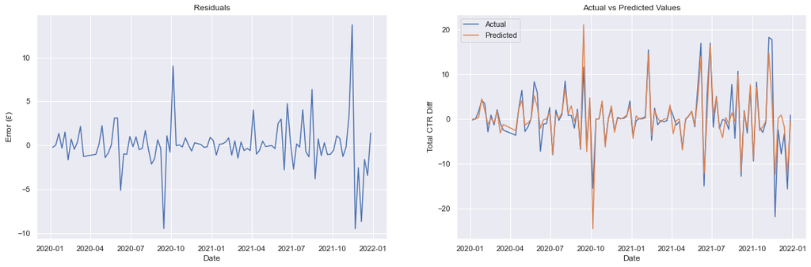

```python
# Upper funnel CTR regression
reg = smf.ols('Total_CTR_Diff ~ In_Market_UF_Diff', data=plo_df).fit()
print(reg.summary())

# Plot residuals and actual vs fitted values
fig, ax = plt.subplots(1, 2, figsize=(20, 6))

ax[0].plot(reg.resid)
ax[0].set_title('Residuals')
ax[0].set_xlabel('Date')
ax[0].set_ylabel('Error ($\epsilon$)')

ax[1].plot(plo_df['Total_CTR_Diff'], label='Actual')
ax[1].plot(reg.fittedvalues, label='Predicted')
ax[1].set_title('Actual vs Predicted Values')
ax[1].set_xlabel('Date')
ax[1].set_ylabel('Total CTR Diff')

ax[1].legend()
plt.show()
```

After differencing the data, the r-squared seems much more reasonable and it is lower than the DW statistic. The regression coefficient on `In_Market_UF_Diff` says that, on average, adding one more upper funnel creative relates to a total monthly CTR increase of 0.1739 points.

```
                                OLS Regression Results
=====================================================================================
Dep. Variable:     Total_Site_Visit_CVR_Diff   R-squared:                       0.875
Model:                                   OLS   Adj. R-squared:                  0.870
Method:                        Least Squares   F-statistic:                     158.2
Date:                       Tue, 05 Apr 2022   Prob (F-statistic):           4.38e-21
Time:                               22:02:34   Log-Likelihood:                -153.18
No. Observations:                         48   AIC:                             312.4
Df Residuals:                             45   BIC:                             318.0
Df Model:                                  2
Covariance Type:                   nonrobust
==============================================================================================
                                 coef    std err          t      P>|t|      [0.025      0.975]
----------------------------------------------------------------------------------------------
Intercept                      0.0549      0.877      0.063      0.950      -1.712       1.822
In_Market_MF_Diff              0.3153      0.035      9.135      0.000       0.246       0.385
Total_Buy_Flow_CVR_MF_Diff     0.0024      0.001      4.807      0.000       0.001       0.003
==============================================================================
Omnibus:                        7.815   Durbin-Watson:                   2.514
Prob(Omnibus):                  0.020   Jarque-Bera (JB):               10.551
Skew:                          -0.433   Prob(JB):                      0.00512
Kurtosis:                       5.127   Cond. No.                     2.39e+03
==============================================================================

Notes:
[1] Standard Errors assume that the covariance matrix of the errors is correctly specified.
[2] The condition number is large, 2.39e+03. This might indicate that there are
strong multicollinearity or other numerical problems.
```

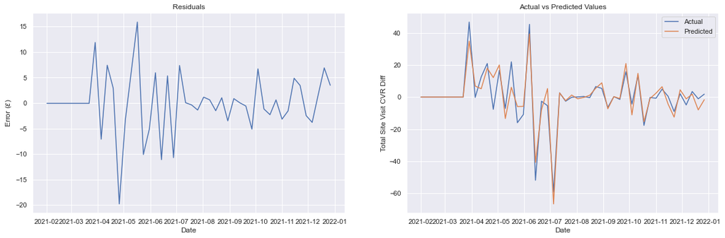

```python
# Middle funnel Site Visit CVR regression
reg = smf.ols('Total_Site_Visit_CVR_Diff ~ In_Market_MF_Diff + Total_Buy_Flow_CVR_MF_Diff', data=plo_df.loc['2021-01-31':]).fit()
print(reg.summary())

# Plot residuals and actual vs fitted values
fig, ax = plt.subplots(1, 2, figsize=(20, 6))

ax[0].plot(reg.resid)
ax[0].set_title('Residuals')
ax[0].set_xlabel('Date')
ax[0].set_ylabel('Error ($\epsilon$)')

ax[1].plot(plo_df.loc['2021-01-31':]['Total_Site_Visit_CVR_Diff'], label='Actual')
ax[1].plot(reg.fittedvalues, label='Predicted')
ax[1].set_title('Actual vs Predicted Values')
ax[1].set_xlabel('Date')
ax[1].set_ylabel('Total Site Visit CVR Diff')

ax[1].legend()
plt.show()
```

The model shows a good fit on the differenced site visit CVR with a high r-squared. The coefficient for `In_Market_MF_Diff` says, on average, adding one more middle funnel creative increases total monthly site visit CVR by 0.3153 points.

```
                                OLS Regression Results
======================================================================================
Dep. Variable:     Total_Buy_Flow_CVR_MF_Diff   R-squared:                       0.473
Model:                                    OLS   Adj. R-squared:                  0.461
Method:                         Least Squares   F-statistic:                     41.21
Date:                        Tue, 05 Apr 2022   Prob (F-statistic):           6.79e-08
Time:                                22:02:34   Log-Likelihood:                -426.06
No. Observations:                          48   AIC:                             856.1
Df Residuals:                              46   BIC:                             859.9
Df Model:                                   1
Covariance Type:                    nonrobust
=====================================================================================
                        coef    std err          t      P>|t|      [0.025      0.975]
-------------------------------------------------------------------------------------
Intercept           -20.8477    255.513     -0.082      0.935    -535.168     493.473
In_Market_MF_Diff    46.8684      7.301      6.419      0.000      32.172      61.565
==============================================================================
Omnibus:                       37.317   Durbin-Watson:                   2.610
Prob(Omnibus):                  0.000   Jarque-Bera (JB):              151.419
Skew:                           1.867   Prob(JB):                     1.32e-33
Kurtosis:                      10.859   Cond. No.                         35.0
==============================================================================

Notes:
[1] Standard Errors assume that the covariance matrix of the errors is correctly specified.
```

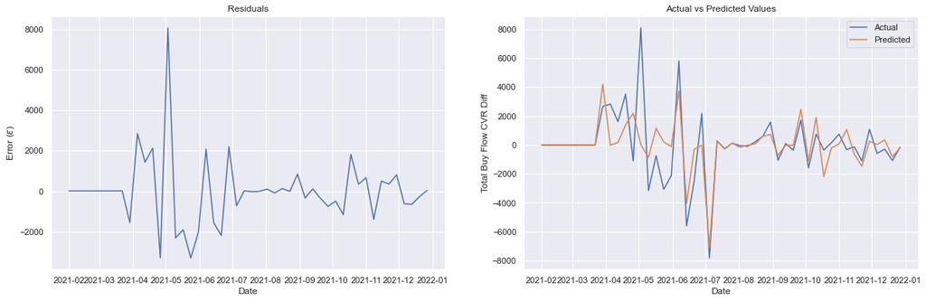

```python
# Middle funnel Buy Flow CVR regression
reg = smf.ols('Total_Buy_Flow_CVR_MF_Diff ~ In_Market_MF_Diff', data=plo_df.loc['2021-01-31':]).fit()
print(reg.summary())

# Plot residuals and actual vs fitted values
fig, ax = plt.subplots(1, 2, figsize=(20, 6))

ax[0].plot(reg.resid)
ax[0].set_title('Residuals')
ax[0].set_xlabel('Date')
ax[0].set_ylabel('Error ($\epsilon$)')

ax[1].plot(plo_df.loc['2021-01-31':]['Total_Buy_Flow_CVR_MF_Diff'], label='Actual')
ax[1].plot(reg.fittedvalues, label='Predicted')
ax[1].set_title('Actual vs Predicted Values')
ax[1].set_xlabel('Date')
ax[1].set_ylabel('Total Buy Flow CVR Diff')

ax[1].legend()
plt.show()
```

The model does not fit as well as the others given its lower r-squared. The `In_Market_MF_Diff` coefficient states that adding one more middle funnel creative increases total monthly buy flow CVR by 46.87 points, on average.

```
                                OLS Regression Results
======================================================================================
Dep. Variable:     Total_Buy_Flow_CVR_LF_Diff   R-squared:                       0.787
Model:                                    OLS   Adj. R-squared:                  0.783
Method:                         Least Squares   F-statistic:                     181.0
Date:                        Tue, 05 Apr 2022   Prob (F-statistic):           1.24e-33
Time:                                22:02:34   Log-Likelihood:                -849.00
No. Observations:                         101   AIC:                             1704.
Df Residuals:                              98   BIC:                             1712.
Df Model:                                   2
Covariance Type:                    nonrobust
========================================================================================
                           coef    std err          t      P>|t|      [0.025      0.975]
----------------------------------------------------------------------------------------
Intercept              -11.2124    109.385     -0.103      0.919    -228.283     205.858
In_Market_LF_Diff      130.0424     13.601      9.561      0.000     103.051     157.034
Total_Sales_CVR_Diff    32.5719      4.406      7.392      0.000      23.828      41.316
==============================================================================
Omnibus:                       21.298   Durbin-Watson:                   2.304
Prob(Omnibus):                  0.000   Jarque-Bera (JB):               92.761
Skew:                          -0.451   Prob(JB):                     7.20e-21
Kurtosis:                       7.607   Cond. No.                         31.7
==============================================================================

Notes:
[1] Standard Errors assume that the covariance matrix of the errors is correctly specified.
```

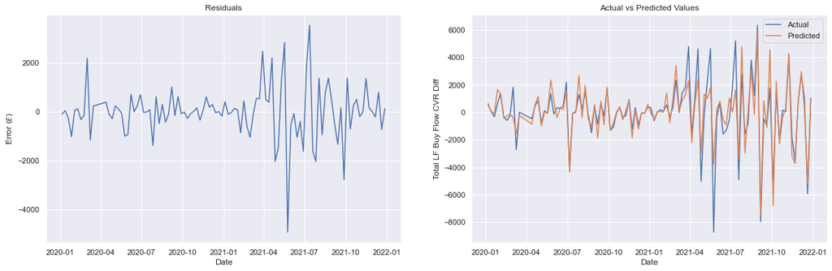

```python
# Lower funnel Buy Flow CVR regression
reg = smf.ols('Total_Buy_Flow_CVR_LF_Diff ~ In_Market_LF_Diff + Total_Sales_CVR_Diff', data=plo_df).fit()
print(reg.summary())

# Plot residuals and actual vs fitted values
fig, ax = plt.subplots(1, 2, figsize=(20, 6))

ax[0].plot(reg.resid)
ax[0].set_title('Residuals')
ax[0].set_xlabel('Date')
ax[0].set_ylabel('Error ($\epsilon$)')

ax[1].plot(plo_df['Total_Buy_Flow_CVR_LF_Diff'], label='Actual')
ax[1].plot(reg.fittedvalues, label='Predicted')
ax[1].set_title('Actual vs Predicted Values')
ax[1].set_xlabel('Date')
ax[1].set_ylabel('Total LF Buy Flow CVR Diff')

ax[1].legend()
plt.show()
```

The fitted model above shows good results with an r-squared of 0.787. Holding all else constant, the affect of adding one more lower funnel creative on total monthly buy flow CVR is 130.04 points, on average.

```
                             OLS Regression Results
================================================================================
Dep. Variable:     Total_Sales_CVR_Diff   R-squared:                       0.362
Model:                              OLS   Adj. R-squared:                  0.355
Method:                   Least Squares   F-statistic:                     56.10
Date:                  Tue, 05 Apr 2022   Prob (F-statistic):           2.92e-11
Time:                          22:02:35   Log-Likelihood:                -467.68
No. Observations:                   101   AIC:                             939.4
Df Residuals:                        99   BIC:                             944.6
Df Model:                             1
Covariance Type:              nonrobust
=====================================================================================
                        coef    std err          t      P>|t|      [0.025      0.975]
-------------------------------------------------------------------------------------
Intercept             0.3294      2.495      0.132      0.895      -4.621       5.280
In_Market_LF_Diff     1.8564      0.248      7.490      0.000       1.365       2.348
==============================================================================
Omnibus:                       13.673   Durbin-Watson:                   2.168
Prob(Omnibus):                  0.001   Jarque-Bera (JB):               38.915
Skew:                          -0.290   Prob(JB):                     3.55e-09
Kurtosis:                       5.985   Cond. No.                         10.1
==============================================================================

Notes:
[1] Standard Errors assume that the covariance matrix of the errors is correctly specified.
```

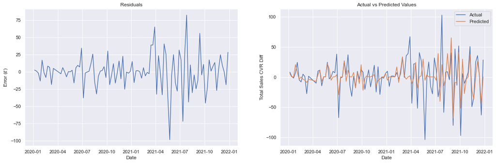

```python
# Lower funnel Sales CVR regression
reg = smf.ols('Total_Sales_CVR_Diff ~ In_Market_LF_Diff', data=plo_df).fit()
print(reg.summary())

# Plot residuals and actual vs fitted values
fig, ax = plt.subplots(1, 2, figsize=(20, 6))

ax[0].plot(reg.resid)
ax[0].set_title('Residuals')
ax[0].set_xlabel('Date')
ax[0].set_ylabel('Error ($\epsilon$)')

ax[1].plot(plo_df['Total_Sales_CVR_Diff'], label='Actual')
ax[1].plot(reg.fittedvalues, label='Predicted')
ax[1].set_title('Actual vs Predicted Values')
ax[1].set_xlabel('Date')
ax[1].set_ylabel('Total Sales CVR Diff')

ax[1].legend()
plt.show()
```

The model fitted on sales CVR shows poor r-squared results, but all models fitted show no signs of spurious regressions. On average, adding one more lower funnel creative increases total monthly sales CVR by 1.86 points, on average.

## Additional Analysis

### What's the average funnel specific KPI behaviour after launch?

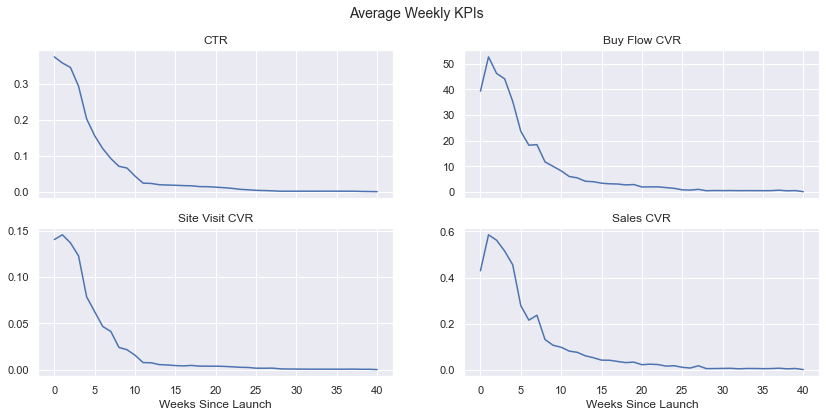

```python
# Plot weekly means
ctr_means = np.mean(week_data[ctr_w])
cvrbf_means = np.mean(week_data[cvrbf_w])
cvrsv_means = np.mean(week_data[cvrsv_w])
cvrint_means = np.mean(week_data[cvrint_w])

kpis = {
    'CTR': ctr_means.values,
    'Buy Flow CVR': cvrbf_means.values,
    'Site Visit CVR': cvrsv_means.values,
    'Sales CVR': cvrint_means.values
}

kpi_means_df = pd.DataFrame(kpis)

fig, ax = plt.subplots(2, 2, figsize=(14, 6), sharex=True)
fig.suptitle('Average Weekly KPIs', fontsize=14)

sns.lineplot(x=range(41), y='CTR', data=kpi_means_df, ax=ax[0,0])
ax[0,0].set_title('CTR')
ax[0,0].set_xlabel('Weeks Since Launch')
ax[0,0].set_ylabel('')

sns.lineplot(x=range(41), y='Buy Flow CVR', data=kpi_means_df, ax=ax[0,1])
ax[0,1].set_title('Buy Flow CVR')
ax[0,1].set_xlabel('Weeks Since Launch')
ax[0,1].set_ylabel('')

sns.lineplot(x=range(41), y='Site Visit CVR', data=kpi_means_df, ax=ax[1,0])
ax[1,0].set_title('Site Visit CVR')
ax[1,0].set_xlabel('Weeks Since Launch')
ax[1,0].set_ylabel('')

sns.lineplot(x=range(41), y='Sales CVR', data=kpi_means_df, ax=ax[1,1])
ax[1,1].set_title('Sales CVR')
ax[1,1].set_xlabel('Weeks Since Launch')
ax[1,1].set_ylabel('')

plt.show()
```

CTRs fall immediately upon launch, whereas BF, SV, and sales increases for a short period. This behaviour seems normal since some people may visit the website but not necessarily by clicking on the creative ad itself. We also see that a creatives life cycle begins to end near week 10 where the "elbow" or "kink" is located.

## Get data ready for modelling

```python
# One hot encode new social channel data and add new feature
final_dummy_data = pd.get_dummies(social_data, columns=cat_data.columns[1:], drop_first=True).drop(columns=['offer_group', 'asset_type'])
final_dummy_data['discount_applied'] = final_dummy_data['discount'].apply(lambda x: 1 if x > 0 else 0)

labeled_social_data.drop(columns=['offer_group', 'asset_type'], inplace=True)
labeled_social_data['discount_applied'] = labeled_social_data['discount'].apply(lambda x: 1 if x > 0 else 0)

# Remove W41 to W47
for week in labeled_social_data.columns:
    if week[-3:] in weeks_to_drop:
        labeled_social_data.drop(columns=week, inplace=True)
```

```python
# Add created features and week features
final_dummy_data = pd.merge(
    final_dummy_data.reset_index(),
    labeled_social_data.iloc[:, 14:29],  # Created features
    left_index=True,
    right_index=True).merge(
        week_data.iloc[:,:-82].reset_index(),  # Remove impressions and spend
        left_on='index',
        right_on='index'
)
final_dummy_data.drop(columns='index', inplace=True)

final_labeled_social_data = pd.merge(
    labeled_social_data.reset_index(),
    week_data.reset_index()[['index']],
    how='inner',
    left_on='index',
    right_on='index'
)

final_labeled_social_data.drop(columns='index', inplace=True)
```

```python
# Reorder discount_applied column
discount = final_labeled_social_data.iloc[:, -1]
created_feat = final_labeled_social_data.iloc[:, 14:29]
final_labeled_social_data = pd.concat(
    [final_labeled_social_data.iloc[:,:14].reset_index(), discount.reset_index(), created_feat.reset_index(),
    week_data.iloc[:,:-82].reset_index()],  # Remove impressions and spend
    axis=1
)
final_labeled_social_data.drop(columns='index', inplace=True)
```

```python
final_dummy_data.to_csv('ML_data/dummy_ml.csv', index=False)
final_labeled_social_data.to_csv('ML_data/labeled_ml.csv', index=False)
```